# Importing Neccessary Packages

```python
import warnings
warnings.filterwarnings('ignore')
import pandas as pd
import numpy as np
import seaborn as sns
sns.set(style="darkgrid")
import matplotlib.pyplot as plt
%matplotlib inline
```

# Load the Dataset

```python
data = pd.read_csv('CardioGoodFitness.csv')
data.head()
```

|  | Product | Age | Gender | Education | MaritalStatus | Usage | Fitness | Income | Miles |
| --- | --- | --- | --- | --- | --- | --- | --- | --- | --- |
| 0 | TM195 | 18 | Male | 14 | Single | 3 | 4 | 29562 | 112 |
| 1 | TM195 | 19 | Male | 15 | Single | 2 | 3 | 31836 | 75 |
| 2 | TM195 | 19 | Female | 14 | Partnered | 4 | 3 | 30699 | 66 |
| 3 | TM195 | 19 | Male | 12 | Single | 3 | 3 | 32973 | 85 |
| 4 | TM195 | 20 | Male | 13 | Partnered | 4 | 2 | 35247 | 47 |

```python
data.shape
```

```
(180, 9)
```

# Observations

We have about 9 Columns and 180 rows in this dataset!!!

# Check the structure of the data

```python
data.info()
```

```
<class 'pandas.core.frame.DataFrame'>
RangeIndex: 180 entries, 0 to 179
Data columns (total 9 columns):
 #   Column         Non-Null Count  Dtype
---  ------         --------------  -----
 0   Product        180 non-null    object
 1   Age            180 non-null    int64
 2   Gender         180 non-null    object
 3   Education      180 non-null    int64
 4   MaritalStatus  180 non-null    object
 5   Usage          180 non-null    int64
 6   Fitness        180 non-null    int64
 7   Income         180 non-null    int64
 8   Miles          180 non-null    int64
dtypes: int64(6), object(3)
memory usage: 12.8+ KB
```

# Summary of the Data

```python
data.describe()
```

|  | Age | Education | Usage | Fitness | Income | Miles |
| --- | --- | --- | --- | --- | --- | --- |
| count | 180.000000 | 180.000000 | 180.000000 | 180.000000 | 180.000000 | 180.000000 |
| mean | 28.788889 | 15.572222 | 3.455556 | 3.311111 | 53719.577778 | 103.194444 |
| std | 6.943498 | 1.617055 | 1.084797 | 0.958869 | 16506.684226 | 51.863605 |
| min | 18.000000 | 12.000000 | 2.000000 | 1.000000 | 29562.000000 | 21.000000 |
| 25% | 24.000000 | 14.000000 | 3.000000 | 3.000000 | 44058.750000 | 66.000000 |
| 50% | 26.000000 | 16.000000 | 3.000000 | 3.000000 | 50596.500000 | 94.000000 |
| 75% | 33.000000 | 16.000000 | 4.000000 | 4.000000 | 58668.000000 | 114.750000 |
| max | 50.000000 | 21.000000 | 7.000000 | 5.000000 | 104581.000000 | 360.000000 |

# Observations

1.Mean Customer age is about 29 years old, and customer ages concentrate between 24 and 33.

2.Mean Customer education is approxiamtely 16 years (Bachelor's Degree), with IQR ranging between 14-16 years.

3.Majority of customers expect to use the treadmill 3 or 4 days/week.

4.Majority of customers rate themselves to be in average to fit physical fitness level.

5.Majority of customers have annual incomes between approx. 45k-60k.

6.Customers expect to run between 66 - 115 miles on their treadmill, with average customer expecting to run 103 miles.

# Checking for missing values

```python
data.isnull().sum()
```

```
Product          0
Age              0
Gender           0
Education        0
MaritalStatus    0
Usage            0
Fitness          0
Income           0
Miles            0
dtype: int64
```

# Observation

No missing value in the dataset

# Checking the skewness in the dataset

```python
data.skew()
```

```
Age          0.982161
Education    0.622294
Usage        0.739494
Fitness      0.454800
Income       1.291785
Miles        1.724497
dtype: float64
```

# Observations

1.Age, Education, and Usage are moderately positively skewed (0.5 < x < 1.0).

2.Income and Miles are highly positively skewed (x > 1.0).

# Plotting Univariate Distributions

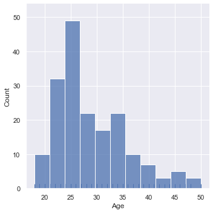

```python
sns.displot(data['Age'], kde=False, rug=True)
plt.show()
```

# Observation

The age of our customers are positively skewed with a higher concentration between 18 years old and 35 years old

# Examine each variables

Analysing the Gender using (Countplot)

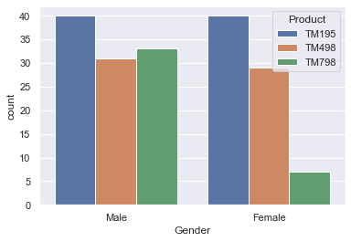

```python
sns.countplot(x='Gender', data=data, hue='Product')
plt.show()
```

# Observations

1.TM195 have similar characteristics in both Male and Female graphical representation above.

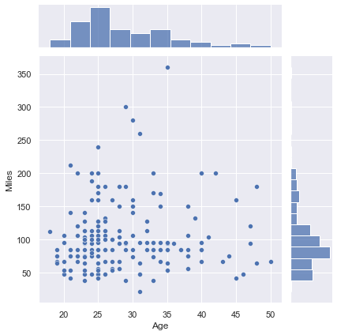

```python
sns.jointplot(data['Age'], data['Miles'])
plt.show()
```

# Observations

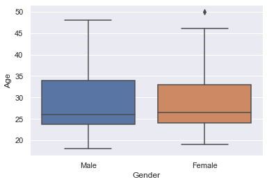

```python
sns.boxplot(x='Gender', data=data, y ='Age')
plt.show()
```

# Observation

1. There are Outlier in the Female Age, while the male age dont have an Outlier

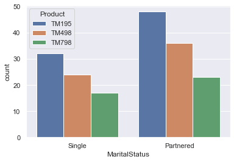

```python
sns.countplot(x='MaritalStatus', data=data, hue='Product')
plt.show()
```

# Observation

# Educational Analysis

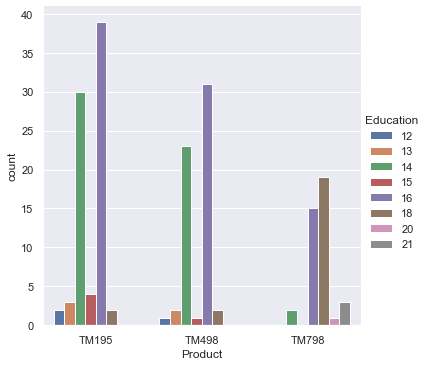

```python
sns.catplot(x='Product', hue = 'Education', kind="count",data=data)
plt.show()
```

# Observations on Product

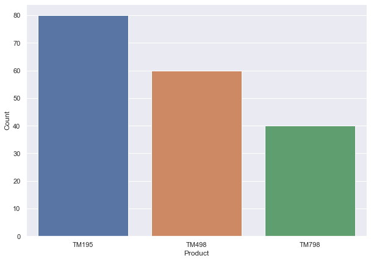

```python
plt.figure(figsize=(10,7))
ax = sns.countplot(data['Product'])
plt.xlabel('Product')
plt.ylabel('Count')


plt.show()
```

# Observations

1. TM195 is most sold product.
2. The number of customers prefering TM195 is most twice as the once prefering TM798.
3. It looks like TM195 is more econamical or popular model compared to the other two models.

# Plotting income summary across different products

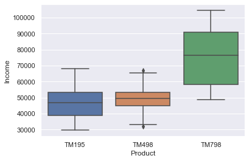

```python
sns.boxplot(data=data, x="Product", y="Income")
plt.show()
```

# Observation

# Plotting income distributions across different products

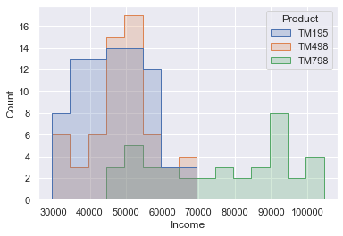

```python
sns.histplot(data=data, x="Income", hue="Product", element="step")
plt.show()
```

# Observation

TM195 and TM498 are popular among middle income customers.

# Checking for Product : Usage vs Gender

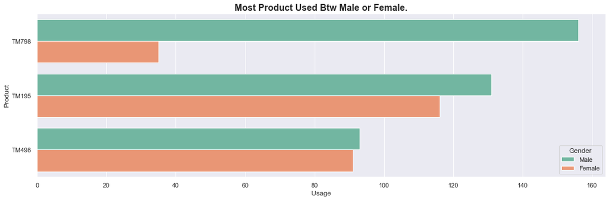

```python
usage_p = data['Usage'].groupby([data['Product'],data['Gender']]).sum()
usage_p= usage_p.reset_index().sort_values(by='Usage',ascending=False)
most_com = usage_p.head(10)

fig = plt.figure(figsize=(15,5))
plt.title('Most Product Used Btw Male or Female.', fontdict={'fontweight':'bold', 'fontsize': 16})

sns.barplot(y='Product', x='Usage',hue='Gender',data=most_com,palette='Set2');

plt.ylabel('Product')
plt.tight_layout()
```

# Observations

1. Generally Male use more product than Female
2. For product TM798 their is a huge usage for Male client over Female while for product TM498, the usage is almost the same.

# Relationship between Products, Miles and Gender

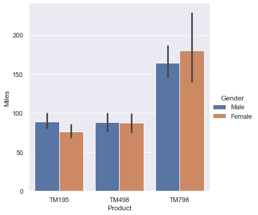

```python
plt.figure(figsize=(10,6))
sns.catplot(x = "Product", y = 'Miles', hue = 'Gender', data = data, kind = 'bar')
plt.show()
```

# Observations

1. TM195 : average planned miles male = 90 ; female = 75.
2. TM498 : average planned miles male = 90 ; female = 90.
3. TM798 : average planned miles male = 160 ; female = 175.
4. Mostly male and female are planning to run equally.
5. Average planned number of miles run by user of TM195 and TM498 are almost similar.
6. Average planned number of miles run by user of TM798 is in the high range.

# Income by gender by product and by marital status

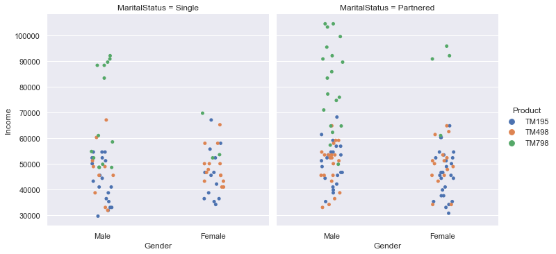

```python
sns.catplot(x='Gender',y='Income', hue='Product', col='MaritalStatus', data=data);
```

# Observation

1. Products TM195 and TM498 are bought by people with lower than $70K as income, single or partnered.
2. We also see that the majority of people who buys the TM798 are man, partnered.
3. The majority of our buyers are man.

# 3. Overview of correlation between variable

```python
data.corr()
```

|  | Age | Education | Usage | Fitness | Income | Miles |
| --- | --- | --- | --- | --- | --- | --- |
| Age | 1.000000 | 0.280496 | 0.015064 | 0.061105 | 0.513414 | 0.036618 |
| Education | 0.280496 | 1.000000 | 0.395155 | 0.410581 | 0.625827 | 0.307284 |
| Usage | 0.015064 | 0.395155 | 1.000000 | 0.668606 | 0.519537 | 0.759130 |
| Fitness | 0.061105 | 0.410581 | 0.668606 | 1.000000 | 0.535005 | 0.785702 |
| Income | 0.513414 | 0.625827 | 0.519537 | 0.535005 | 1.000000 | 0.543473 |
| Miles | 0.036618 | 0.307284 | 0.759130 | 0.785702 | 0.543473 | 1.000000 |

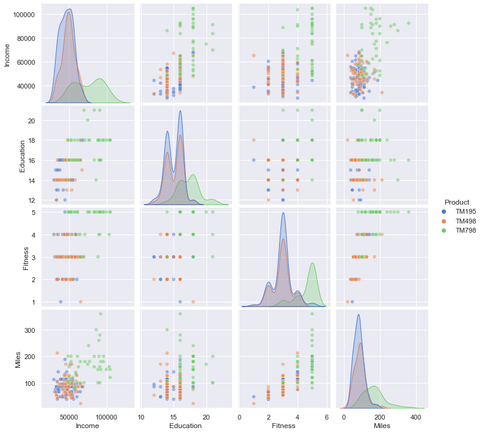

```python
sns.pairplot(data, vars=["Income", "Education", "Fitness", "Miles"],
             hue='Product', palette='muted',
             plot_kws={'alpha': 0.5})
plt.show()
```

# Observation

Customers of TM195 and TM498 appear to be having similar features with minor differences. TM798 is more appealing to the highly educated group who has more expendable income and more conscious about their fit wellness.

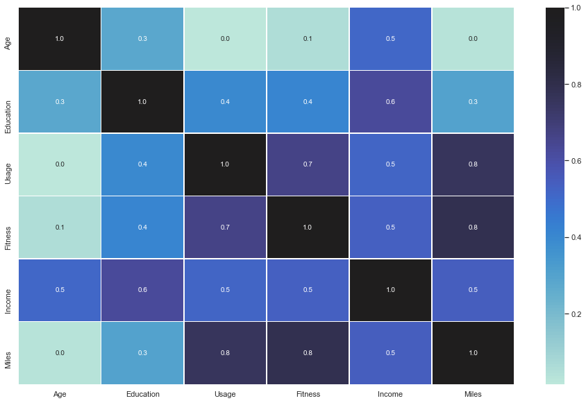

```python
plt.figure(figsize=(16,10))
sns.heatmap(data.corr(), annot=True, linewidth=.5, fmt= '.1f', center = 1);
```